# Enonkishu Conservancy NDVI time series example

Guy Lomax

2023-03-31

## Generating high-resolution NDVI time series

Sentinel-2 provides global satellite imagery at 5-day intervals and at 10-meter resolution, making it one of the most precise freely available satellite datasets currently available. Sentinel-2 imagery at 5-day intervals is available for East Africa from early 2017, providing about six years of continuous data.

The fine resolution of Sentinel-2 allows us to understand vegetation patterns and change on smaller scales than previously possible, to more easily distinguish between open areas and tree- or shrub-covered areas, and to connect remote sensing data to field data collected at the level of individual sample plots or transects.

I have selected six sample points in and around Enonkishu Conservancy to demonstrate the time series analysis. For each point, I have extracted the NDVI (Normalised Difference Vegetation Index) values for all Sentinel-2 images of that location from 2017-2022 at 10m resolution.

The location of the points and the raw time series data are shown below:

[interactive chart not shown]

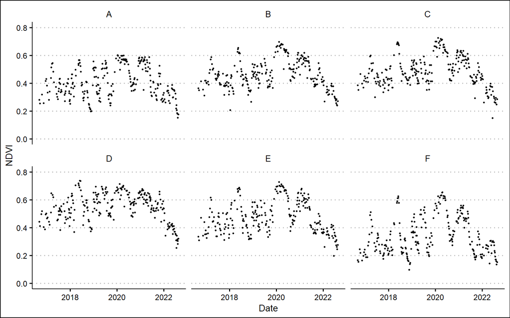

The raw data is quite noisy and has some missing values due to cloud cover, but we can clean this up by using an intelligent smoothing method that reconstructs the original, smooth values.

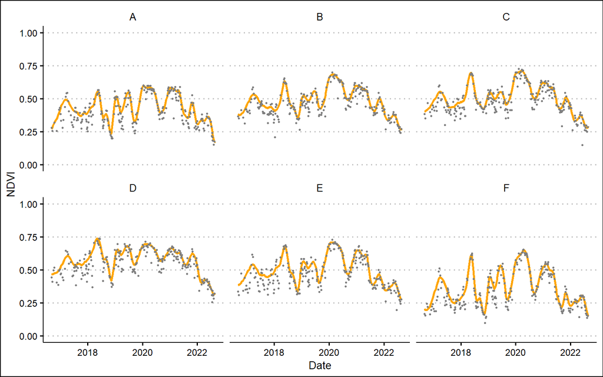

We can use these curves to extract some useful measures, such as productivity, rain use efficiency and recovery rate.

## Extracting NDVI recovery and decay rates from satellite data

```
#> Fitting time - growth:  0.1738439
```

```
#> Fitting time - decay:  0.1568789
```

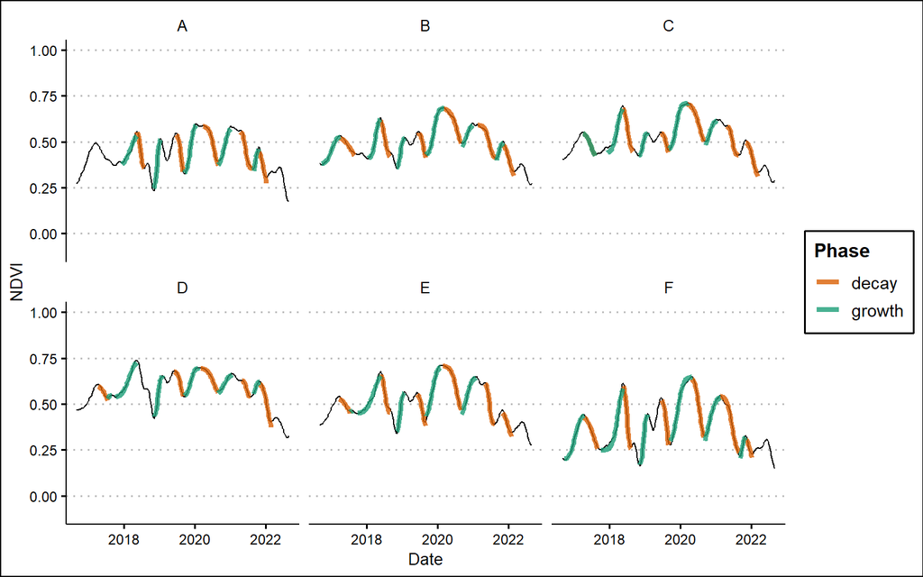

[output not shown]

From here, we could use these data in a few different ways:

1. We could compare some of these metrics between different grazing blocks or look at how boma placement is affecting the vegetation.
2. We could examine the drivers behind the differences in growth or decay rates, for example distinguishing the effects of rainfall, soil type or management.
3. We could compare these metrics between regions with similar areas outside Enonkishu to understand or demonstrate impact.
4. We could compare these metrics to field vegetation monitoring data to see if it is able to capture other metrics of interest on the ground.